# ku_enm: calibration results

### Brief description of the model calibration and selection process

This is the final report of the ku_enm_ceval function implemented in the ku_enm R package.

In all, 30 candidate models, with parameters reflecting all combinations of 5 regularization multiplier settings, 3 feature class combinations, and 2 distinct sets of environmental variables, have been evaluated. Model peformance was evaluated based on statistical significance (Partial_ROC), omission rates (OR), and the Akaike information criterion corrected for small sample sizes (AICc).

Table 1. Parameters of the candidate models.

|  | Parameters |
| --- | --- |
| Regularization multipliers | 0.1, 0.5, 1, 1.5, 2 |
| Feature classes | l, lq, lqp |
| Sets of predictors | Set_1, Set_2 |

The results presented below can be found in the calibration output folder if desired for further analyses.

### Model calibration statistics

In the following table is information about how many models met the four selection criteria that this function uses.

Table 2. General statistics of models that met distinct criteria.

| Criteria | Number_of_models |
| --- | --- |
| All candidate models | 30 |
| Statistically significant models | 30 |
| Models meeting omission rate criteria | 19 |
| Models meeting AICc criteria | 1 |
| Statistically significant models meeting omission rate criteria | 19 |
| Statistically significant models meeting AICc criteria | 1 |
| Statistically significant models meeting omission rate and AICc criteria | 1 |

### Best models according to user-defined criteria

The following table contains the best models selected according to the user's pre-defined criteria.

Note that if the selection criterion was "OR_AICc", models below the omission rate and among them those with lower AICc values, delta AICc values were recalculated only among models meeting the omission rate criterion (*E*).

Table 3. Performance statistics for the best models selected based on the user's pre-defined critera.

| Model | Mean_AUC_ratio | Partial_ROC | Omission_rate_at_5% | AICc | delta_AICc | W_AICc | num_parameters |
| --- | --- | --- | --- | --- | --- | --- | --- |
| M_0.1_F_lq_Set_2 | 1.585 | 0 | 0.031 | 1109.432 | 0 | 0.74 | 4 |

### Model performance plot

The figure below shows the position of the selected models in the distribution of all candidate models in terms of statistical significance, omission rates, and AICc values.

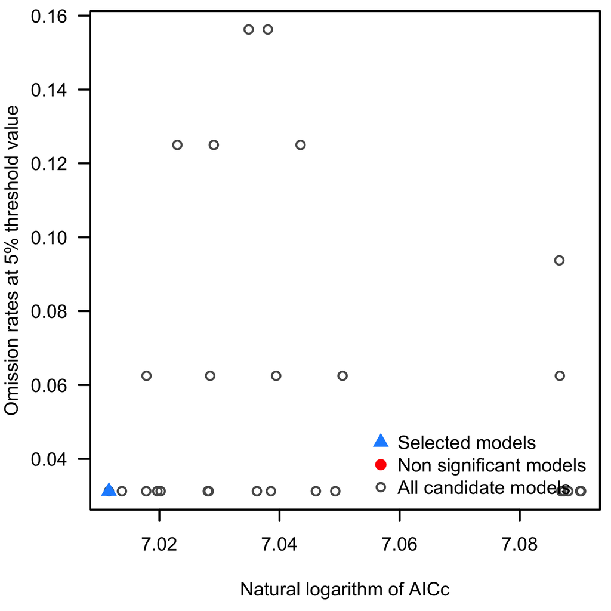

Figure 1. Distribution of all models, non-statistically significant models, and selected models in terms of the user's pre-defined criteria.

### Performance statistics for all models

Following are the performance statistics for all candidate models (a sample if more than 500 models). See file calibration_results.csv for the complete list.

Table 4. Performance statistics for all candidate models.

[output not shown]